# RCode and Instructions for Figure 3

## Table of Contents

### Preliminaries

We share the code that can be used to reproduce the LMMs in our paper and the corresponding plots in Figure 3 in our paper (Vlachou and Macdonald 2024). To reproduce our results in Section 6, you need to: (i) install R, (ii) install RStudio (a version compatible with R and suited to your operating system), or alternatively use RStudio Desktop and import the datasets. Then, you need to make sure you have installed the required libraries, specifically lme4 (Bates et al. 2009) and ggplot2 (Wickham, Chang, and Wickham 2016):

```r
library(lme4) #for LMMs
library(ggplot2) #for plots
```

When this is done, just load the per query sARE datatsets for each evaluation metric. Remember that we apply our LMMs on each metric separately. In this tutorial, we will demonstrate a few examples, but the reader can use it on any metric and retrieval method, simply by replacing with another csv file or by producing their own per query sARE files.

```r
############# Load datatsets with per query sARE ###########################################
######## MAP@100 ######
all_map <- read.csv("all_preds_map.csv", header=TRUE)
## rename variables of interest
names(all_map)[names(all_map) == "sare"] <- "sARE"
names(all_map)[names(all_map) == "source"] <- "predictor"
names(all_map)[names(all_map) == "cat"] <- "QType"
### convert query type to factor variable
all_map$QType<-as.factor(all_map$QType)
all_map$sARE<-abs(all_map$sARE)
## convert qpp predictor to factor variable
all_map$pred_cat<-as.factor(all_map$predictor)
#levels(all_map$pred_cat)
## rename levels of qpp predictor variable to actual predictor names
levels(all_map$pred_cat) <- c("WAND-embs","WD-embs", "AC-embs", "PairRatio", "A-PairRatio", "BERT(bi)","BERT(ce)","monoT5","MAX", "NQC", "RSD")
names(all_map)[names(all_map) == "pred_cat"] <- "Predictor"

####### NDCG@10 ###### repeat process as above
all_ndcg <- read.csv("sARE_ndcg_tct_all.csv", header=TRUE)
names(all_ndcg)[names(all_ndcg) == "sare"] <- "sARE"
names(all_ndcg)[names(all_ndcg) == "source"] <- "predictor"
names(all_ndcg)[names(all_ndcg) == "cat"] <- "QType"

all_ndcg$QType<-as.factor(all_ndcg$QType)
all_ndcg$sARE<-abs(all_ndcg$sARE)
all_ndcg$pred_cat<-as.factor(all_ndcg$predictor)
#levels(all_ndcg$pred_cat)
levels(all_ndcg$pred_cat) <- c("WAND-embs","WD-embs", "AC-embs", "PairRatio", "A-PairRatio", "BERT(bi)","BERT(ce)","monoT5","MAX", "NQC", "RSD")
names(all_ndcg)[names(all_ndcg) == "pred_cat"] <- "Predictor"

###### MRR@10 #####
all_mrr <- read.csv("sARE_mrr_tct_all.csv", header=TRUE) ## repeat process as above to get MRR results
```

In any case, the resulting dataset should have the following form:

```r
head(all_map)
```

```
##   X    qid map      sARE predictor collection          QType   Predictor
## 1 0 855410   1 0.9534884         4          0 EVIDENCE-BASED A-PairRatio
## 2 1 855410   1 0.1627907         5          0 EVIDENCE-BASED    BERT(bi)
## 3 2 855410   1 0.4186047         2          0 EVIDENCE-BASED     AC-embs
## 4 3 855410   1 0.3488372         6          0 EVIDENCE-BASED    BERT(ce)
## 5 4 855410   1 0.7906977        10          0 EVIDENCE-BASED         RSD
## 6 5 855410   1 0.9534884         3          0 EVIDENCE-BASED   PairRatio
```

```r
tail(all_map)
```

```
##        X    qid        map       sARE predictor collection   QType Predictor
## 1062 588 405163 0.02187421 0.03703704         9          1 FACTOID       NQC
## 1063 589 405163 0.02187421 0.12962963         3          1 FACTOID PairRatio
## 1064 590 405163 0.02187421 0.03703704        10          1 FACTOID       RSD
## 1065 591 405163 0.02187421 0.00000000         7          1 FACTOID    monoT5
## 1066 592 405163 0.02187421 0.31481481         0          1 FACTOID WAND-embs
## 1067 593 405163 0.02187421 0.68518519         1          1 FACTOID   WD-embs
```

This dataset contains the query id, the evaluation metric value (per query), the per query sARE, the QPP predictor coded with a number, the collection the query belongs to (DL 19 or 20), the query type resulting from the classifier proposed in the original study (Bolotova et al. 2022), and the QPP predictor expressed in words. Having obtained our dataset, we can now apply the LMMs.

### Linear Mixed Models

We now apply the LMMs in the order proposed in Section 6.

#### LMM definition and output

We start with LMM_average, and then we add sequentially: first, we move to LMM_QPP (add level 1 predictor) and then to LMM_full (add level 2 predictor). We demonstrate an example with MAP that shows the fitting and the output of the three models for TCT-ColBERT. We can see the output of each model by obtaining a summary. The models output the deviance for each model. For significance of single fixed effect terms, please consider the t-value, or the combination of the estimate and the standard error in the output. Each model also outputs the variance components (Variance in Random effects) for each level.

```r
################# FIT LMM MODELS ########################
######## MAP ALL MODELS ###################
#LMM_average
umm_map <- lmer(sARE ~ 1 + (1|qid), REML="false", data = all_map)
summary(umm_map)
```

```
## Linear mixed model fit by maximum likelihood  ['lmerMod']
## Formula: sARE ~ 1 + (1 | qid)
##    Data: all_map
##
##      AIC      BIC   logLik deviance df.resid
##   -400.7   -385.8    203.4   -406.7     1064
##
## Scaled residuals:
##     Min      1Q  Median      3Q     Max
## -1.9734 -0.7588 -0.1661  0.6287  3.6318
##
## Random effects:
##  Groups   Name        Variance Std.Dev.
##  qid      (Intercept) 0.007136 0.08447
##  Residual             0.036000 0.18974
## Number of obs: 1067, groups:  qid, 97
##
## Fixed effects:
##             Estimate Std. Error t value
## (Intercept)  0.26469    0.01036   25.55
```

```r
#LMM_QPP
ugm_map <- lmer(sARE ~ 1 + predictor + (1+predictor|qid), REML="false", data = all_map)
summary(ugm_map)
```

```
## Linear mixed model fit by maximum likelihood  ['lmerMod']
## Formula: sARE ~ 1 + predictor + (1 + predictor | qid)
##    Data: all_map
##
##      AIC      BIC   logLik deviance df.resid
##   -454.2   -424.4    233.1   -466.2     1061
##
## Scaled residuals:
##     Min      1Q  Median      3Q     Max
## -2.2211 -0.7072 -0.1278  0.5843  3.7354
##
## Random effects:
##  Groups   Name        Variance  Std.Dev. Corr
##  qid      (Intercept) 0.0098361 0.09918
##           predictor   0.0002819 0.01679  -0.56
##  Residual             0.0317496 0.17818
## Number of obs: 1067, groups:  qid, 97
##
## Fixed effects:
##              Estimate Std. Error t value
## (Intercept)  0.315782   0.014337  22.026
## predictor   -0.010219   0.002425  -4.213
##
## Correlation of Fixed Effects:
##           (Intr)
## predictor -0.705
```

```r
#LMM_full (= model with group-level predictors)
mp_map<- lmer(sARE ~ 1 + predictor* QType +  (1+predictor|qid), REML="false", data = all_map)
summary(mp_map)
```

```
## Linear mixed model fit by maximum likelihood  ['lmerMod']
## Formula: sARE ~ 1 + predictor * QType + (1 + predictor | qid)
##    Data: all_map
##
##      AIC      BIC   logLik deviance df.resid
##   -451.4   -371.8    241.7   -483.4     1051
##
## Scaled residuals:
##     Min      1Q  Median      3Q     Max
## -2.1691 -0.7077 -0.1209  0.5796  3.7389
##
## Random effects:
##  Groups   Name        Variance  Std.Dev. Corr
##  qid      (Intercept) 0.0096128 0.09804
##           predictor   0.0002174 0.01474  -0.58
##  Residual             0.0317500 0.17819
## Number of obs: 1067, groups:  qid, 97
##
## Fixed effects:
##                                Estimate Std. Error t value
## (Intercept)                    0.321928   0.020702  15.550
## predictor                     -0.010486   0.003317  -3.162
## QTypeEXPERIENCE               -0.114015   0.141928  -0.803
## QTypeFACTOID                  -0.005810   0.029967  -0.194
## QTypeINSTRUCTION              -0.006610   0.083668  -0.079
## QTypeNOT-A-QUESTION           -0.015374   0.141928  -0.108
## QTypeREASON                   -0.050727   0.073194  -0.693
## predictor:QTypeEXPERIENCE      0.051059   0.022739   2.245
## predictor:QTypeFACTOID        -0.001838   0.004801  -0.383
## predictor:QTypeINSTRUCTION    -0.007827   0.013405  -0.584
## predictor:QTypeNOT-A-QUESTION -0.026723   0.022739  -1.175
## predictor:QTypeREASON          0.025579   0.011727   2.181
##
## Correlation of Fixed Effects:
##             (Intr) prdctr QTEXPE QTFACT QTINST QTNOT- QTREAS p:QTEX p:QTFA
## predictor   -0.721
## QTEXPERIENC -0.146  0.105
## QTypFACTOID -0.691  0.498  0.101
## QTINSTRUCTI -0.247  0.178  0.036  0.171
## QTNOT-A-QUE -0.146  0.105  0.021  0.101  0.036
## QTypeREASON -0.283  0.204  0.041  0.195  0.070  0.041
## p:QTEXPERIE  0.105 -0.146 -0.721 -0.073 -0.026 -0.015 -0.030
## p:QTFACTOID  0.498 -0.691 -0.073 -0.721 -0.123 -0.073 -0.141  0.101
## p:QTINSTRUC  0.178 -0.247 -0.026 -0.123 -0.721 -0.026 -0.050  0.036  0.171
## p:QTNOT-A-Q  0.105 -0.146 -0.015 -0.073 -0.026 -0.721 -0.030  0.021  0.101
## pr:QTREASON  0.204 -0.283 -0.030 -0.141 -0.050 -0.030 -0.721  0.041  0.195
##             p:QTIN p:QTNO
## predictor
## QTEXPERIENC
## QTypFACTOID
## QTINSTRUCTI
## QTNOT-A-QUE
## QTypeREASON
## p:QTEXPERIE
## p:QTFACTOID
## p:QTINSTRUC
## p:QTNOT-A-Q  0.036
## pr:QTREASON  0.070  0.041
```

Now we continue with the corresponding LMMs for NDCG.

```r
####### NDCG ALL MODELS ########
umm_ndcg <- lmer(sARE ~ 1 + (1|qid), REML="false", data = all_ndcg)
#summary(umm_ndcg) ### uncomment this part to get the summary of the model results

ugm_ndcg <- lmer(sARE ~ 1 + predictor + (1+predictor|qid), REML="false", data = all_ndcg)
#summary(ugm_ndcg)

mp_ndcg<- lmer(sARE ~ 1 + predictor* QType +  (1+predictor|qid), REML="false", data = all_ndcg)
#summary(mp_ndcg)
#### repeat process for MRR@10 ####
```

After demonstrating how we obtain the LMMs for TCT-ColbERT, we can easily obtain the ones for ANCE and BM25 by using the corresponding csv input files. Alternatively, you can crete your own input files, as described above.

#### Visual Inspection

This is the part where we reproduce the plots in Figure 3 of the paper. Specifically, we compare and contrast the full models for MAP and NDCG (LMM_full), as defined above.

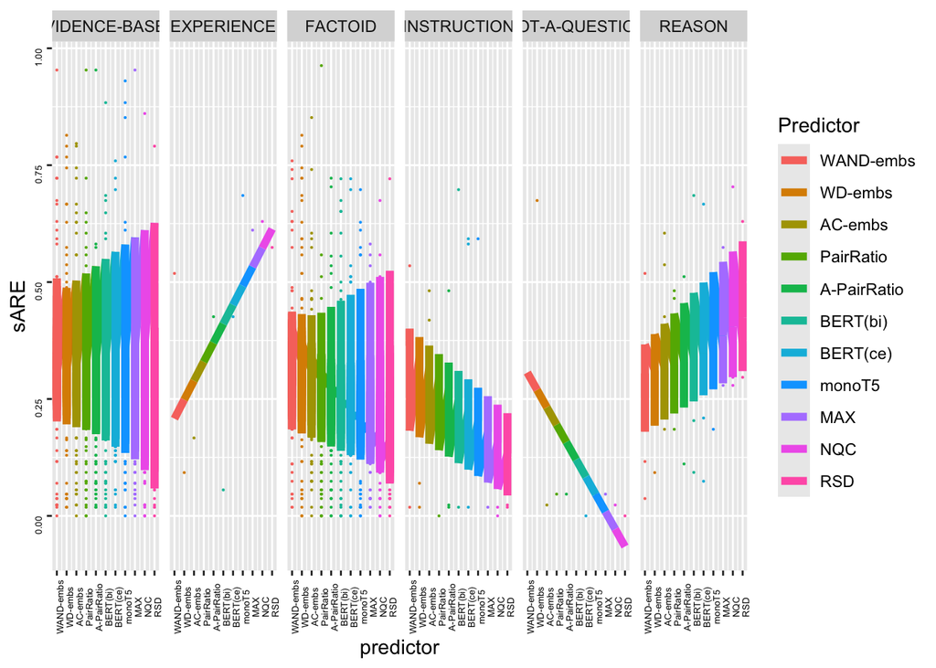

```r
######## PLOTS for Figure 3 ######
##### MAP #####
ggplot(all_map, aes(x=predictor, y=sARE, colour=Predictor)) +
  facet_grid(~QType) +
  geom_point(size=0.1) +
  geom_line(aes(y=predict(mp_map),group=QType,
                color=Predictor),size=2) +
  scale_x_continuous(breaks=seq(0, 10, 1),
                     labels=c("WAND-embs","WD-embs", "AC-embs", "PairRatio", "A-PairRatio", "BERT(bi)","BERT(ce)","monoT5","MAX", "NQC", "RSD")) +
  theme(axis.text.x = element_text(color="black",
                                   size=5, angle=90),
        axis.text.y = element_text(color="black",
                                   size=5, angle=90)) +
  scale_color_hue(labels=c("Control" = "W-embs","WD-embs", "AC-embs", "PairRatio", "A-PairRatio", "BERT(bi)","BERT(ce)","monoT5","MAX", "NQC", "RSD"))
```

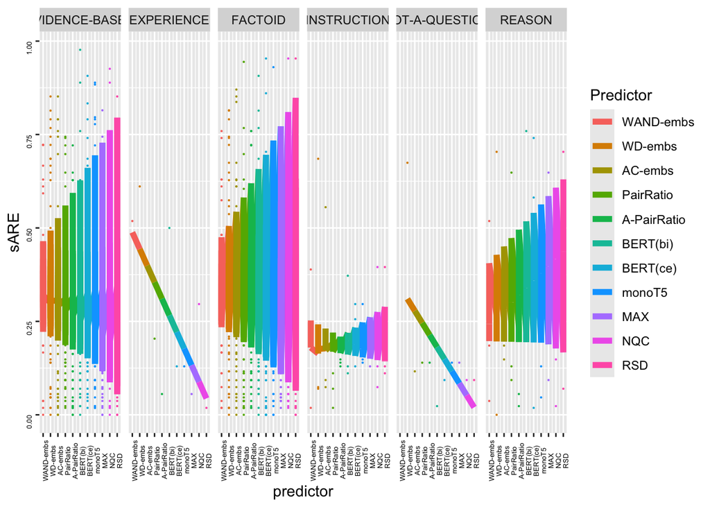

```r
######## NDCG ############
ggplot(all_ndcg, aes(x=predictor, y=sARE, colour=Predictor)) +
  facet_grid(~QType) +
  geom_point(size=0.1) +
  geom_line(aes(y=predict(mp_ndcg),group=QType,
                color=Predictor),size=2) +
  scale_x_continuous(breaks=seq(0, 10, 1),
                     labels=c("WAND-embs","WD-embs", "AC-embs", "PairRatio", "A-PairRatio", "BERT(bi)","BERT(ce)","monoT5","MAX", "NQC", "RSD")) +
  theme(axis.text.x = element_text(color="black",
                                   size=5, angle=90),
        axis.text.y = element_text(color="black",
                                   size=5, angle=90)) +
  scale_color_hue(labels=c("Control" = "W-embs","WD-embs", "AC-embs", "PairRatio", "A-PairRatio", "BERT(bi)","BERT(ce)","monoT5","MAX", "NQC", "RSD"))
```

## References

Bates, Douglas, Martin Maechler, Ben Bolker, Steven Walker, Rune Haubo Bojesen Christensen, Henrik Singmann, Bin Dai, Fabian Scheipl, and Gabor Grothendieck. 2009. “Package ‘Lme4’.”

Bolotova, Valeriia, Vladislav Blinov, Falk Scholer, W Bruce Croft, and Mark Sanderson. 2022. “A Non-Factoid Question-Answering Taxonomy.” In *Proc. SIGIR*.

Vlachou, Maria, and Craig Macdonald. 2024. “Coherence-Based Query Performance Measures for Dense Retrieval.” In *Proc. ICTIR*.

Wickham, Hadley. 2017. *Tidyverse: Easily Install and Load the ’Tidyverse’*. https://CRAN.R-project.org/package=tidyverse.

Wickham, Hadley, Winston Chang, and Maintainer Hadley Wickham. 2016. “Package ‘Ggplot2’.” *Create Elegant Data Visualisations Using the Grammar of Graphics. Version* 2 (1): 1–189.